# Math 421 - Midterm

## III. Predictive Models

Continue with the data from part I. Make sure you do not have any missing values in the data. Use the follows as the target and input variables:

*Target Variable*: Create the target variable taking value of

- `low` if the total charge of a patient (`tot`) is smaller than the median of the total charge, and
- `high` otherwise.

*Input Variables*:

- “age”,“sex”,“raceethn”,“provider”,“moa”,“mod”,“admtype”,“campus”, ‘los’
1. Use `filter` function to filter out rows where `raceethn==''` or `admtype==''`. Make sure all the categorical variables are factor, numeric variables are numeric. Set Training : Testing Split = 10 : 90

```r
library(haven)
library(tidyverse)
library(caret)
df3 = read_csv('midterm.csv')

df3 = df3 %>% select("age","sex","provider","moa","mod","campus", "los", "tot")


df3$target <- ifelse(df3$tot<median(df3$tot),
                        'low','high')

df3 = df3 %>% select(-tot)

splitIndex <- createDataPartition(df3$target, p = .10,
                                  list = FALSE)
df_train <- df3[ splitIndex,]
df_test <- df3[-splitIndex,]
```

2. Train a decision tree using `rpart`. Plot the decision tree. Plot the variable importance ranked by the tree.

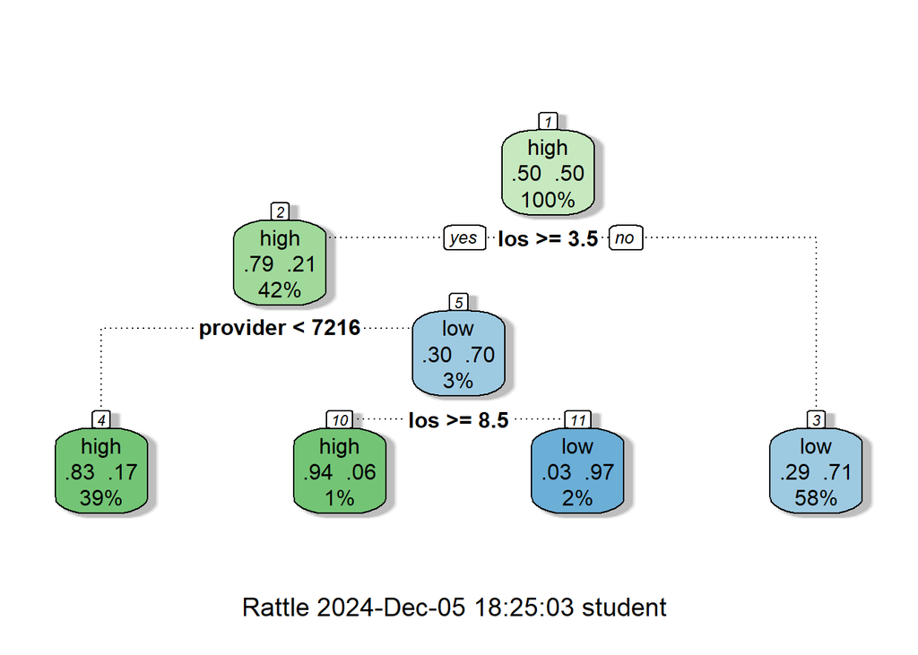

```r
library(rpart)
tree_model <- rpart(target ~ ., data = df_train,
                 control = rpart.control(maxdepth = 3))
library(rattle)
fancyRpartPlot(tree_model)
```

```r
tree_model$variable.importance
```

```
##        los   provider        age     campus
## 1786.33192  328.06197   33.01998   31.62604
```

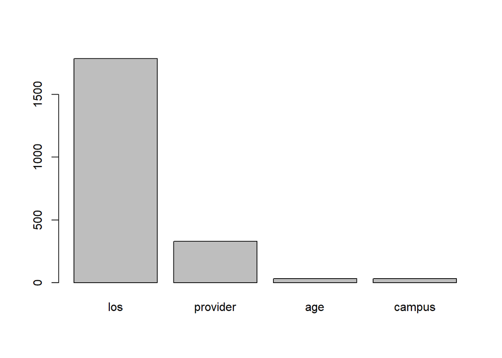

```r
barplot(tree_model$variable.importance)
```

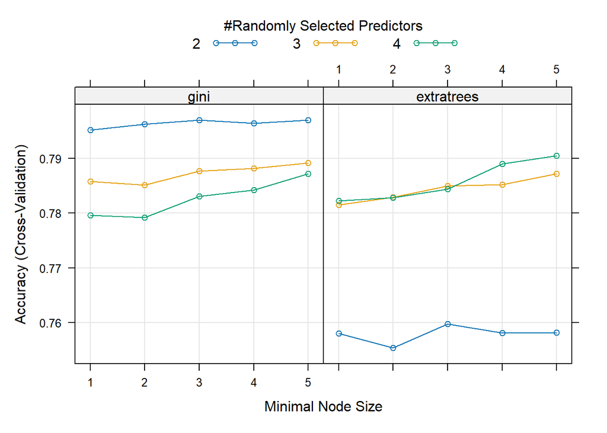

```r
library(caret)
trControl = trainControl(method = "cv",
                         number = 5)
tuneGrid = expand.grid(mtry = 2:4,
                       splitrule = c('gini', 'extratrees'),
                       min.node.size = c(1:5))
forest_ranger <- train(target~., data=df_train,
                                method = "ranger",
                                trControl = trControl,
                                tuneGrid = tuneGrid)
plot(forest_ranger)
```

```r
pred <- predict(forest_ranger, df_test)
df_test$target <- as.factor(df_test$target)
pred <- factor(pred, levels = levels(df_test$target))
cm <- confusionMatrix(data = pred, reference = df_test$target)
cm$overall[1]
```

```
##  Accuracy
## 0.7923332
```